```python
%matplotlib nbagg
```

# Projet de Simulation et Monte Carlo

# Sujet : Queue d'attente

Projet réalisé par C. Cony, P. Carles et G. Demonet  
Enseignant supervisant le projet : C. Findling

## Enoncé

Une queue d'attente a les caractéristiques suivantes : le **temps entre deux arrivées** (notons-le `delta`) suit une loi exponentielle de paramètre `lambda_1`, et le **temps de service d'un client** (notons-le `service`) suit une loi exponentielle de paramètre `lambda_2`. On souhaite estimer la probabilité que le nombre de clients dans la salle d'attente dépasse un certain seuil critique `n` entre le temps 0 et le temps `t`.

1. Simuler la queue d'attente, et expliquer comment varie cette probabilité en fonction de `lambda_1`, `lambda_2`, `n` et `t`.
2. Dans le cas où cette probabilité est très petite, on se propose d'appliquer la méthode de l'entropie croisée. Expliquer comment appliquer cette méthode dans ce cas précis, et l'appliquer pour un certain jeu de paramètres `lambda_1`, `lambda_2`, `n` et `t`.
3. Reprendre cet exercice en remplaçant les lois exponentielles par des lois de Weibul.

Note : une difficulté de l'exercice est que le nombre de variables devant être simulées entre le temps 0 et le temps `t` est lui-même aléatoire, bien expliquer comment vous avez traité ce problème.

## Documentation utile

- [Théorie des files d'attente](https://fr.wikipedia.org/wiki/Th%C3%A9orie_des_files_d%27attente)
- [Notation de Kendall](https://fr.wikipedia.org/wiki/Notation_de_Kendall)
- [Loi exponentielle](https://fr.wikipedia.org/wiki/Loi_exponentielle)
- [Loi de Weibull](https://fr.wikipedia.org/wiki/Loi_de_Weibull)
- [Méthode de l'entropie croisée](https://fr.wikipedia.org/wiki/M%C3%A9thode_de_l%27entropie_crois%C3%A9e) *([en anglais, plus large](http://iew3.technion.ac.il/CE/))*

**Note** : on a remarqué que [ce papier](http://www.maths.uq.edu.au/~kroese/ps/dpr_ms.pdf) correspond au problème de la question 2, avec une approche un peu plus générale. De plus, [celui-ci](http://www.maths.uq.edu.au/~kroese/ps/aortut.pdf) offre quelques exemples d'application de la méthode *CE*.

## Approche du sujet et méthode

La file d'attente de la première partie du sujet est du type classique **M/M/1** (décrit [ici](http://www.win.tue.nl/~iadan/que/h4.pdf)), on supposera également ici que les clients sont traités un à un suivant la règle du *First In First Out*.

Une représentation markovienne du processus est la suivante (en prenant pour lambda `lambda_1` et pour mu `lambda_2`) :

[figure not shown]

source: Wikipedia

La *loi de Little* nous donne le nombre moyen de clients dans notre file en régime stationnaire, à condition qu'elle soit stable. Sachant que l'espérance d'une exponentielle est l'inverse de son paramètre, le nombre moyen de clients en régime stationnaire est alors dans notre cas `lambda_1`/`lambda_2`.

Mais l'objet du sujet n'est pas le régime stationnaire mais l'ensemble des régimes, incluant le régime transient. Il semble que ce régime ait été traité analytiquement dans ["*Transient behavior of the M/M/1 queue : starting at the origin*"](http://www.columbia.edu/~ww2040/TransientMM1questa.pdf), J. Abate and W. Whitt, 1986. Nous pourrons peut-être comparer nos résultats aux formules explicites que les auteurs ont obtenues.

```python
# Importation des modules nécessaires au projet
# from __future__ import print_function
import numpy as np
from numpy.random import exponential, weibull
from time import time
import math
import matplotlib.pyplot as plt
from mpl_toolkits.mplot3d import Axes3D
from matplotlib import cm
from ipywidgets import interact, interactive, fixed
import ipywidgets as widgets
```

### Simulation de la file d'attente

Pour simuler la file d'attente, on choisira d'employer une méthode séquentielle, similaire au cas réel (cette méthode intuitive est appelée [**Simulation à évènements discrets**](https://fr.wikipedia.org/wiki/Simulation_%C3%A0_%C3%A9v%C3%A9nements_discrets)). Ainsi, le processus suivant décrit cette méthode (**Reprendre sans variables**) :

1. Définition des paramètres `(n, t, lambda_1, lambda_2)`, en fixant `i`, `delta`, et `service` à 0 pour initialiser (*on suppose que 0 est le temps d'arrivée du premier client*). On fixe aussi notre variable de comptage `ql` (pour *queue length*) à 1.
2. Tant que (`i < t`) :
   - Si (`ql > n`), on conserve cette information dans une variable globale booléenne `over`.
   - Si (`service = 0`), alors : (*cas où à l'étape d'avant, un client a été servi et part*)
     - Tirer une valeur de `service`. (*sinon, on garde la précédente*)
   - Si (`delta = 0`), alors : (*cas où à l'étape d'avant, un client arrive*)
     - Tirer une valeur de `delta`. (*sinon, on garde la précédente*)
   - Si (`delta < service`), alors : (*un client arrive avant qu'un autre soit servi*)
     - On enlève `delta` de `service`. (*temps restant avant le prochain servi*)
     - On ajoute `delta` à `i`.
     - On réinitialise `delta` à 0.
     - On incrémente `ql` de 1.
   - Sinon si (`ql > 0`) : (*un client est servi avant qu'un autre n'arrive, à condition qu'il y en ait un*)
     - On enlève `service` de `delta`. (*temps restant avant la prochaine arrivée*)
     - On ajoute `service` à `i`.
     - On réinitialise `service` à 0.
     - On décrémente `ql` de 1.
   - Sinon : (*on attend juste un nouveau client*)
     - On ajoute `delta` à `i`.
     - On réinitialise `delta` et `ql` à 0 et 1 resp.

Ce processus de simulation, en l'itérant, nous permet d'estimer la probabilité de `over`, autrement dit la probabilité que la file ait dépassé le seuil `n`. Pour tirer selon les lois exponentielles ou de Weibull, on utilisera le module `numpy.random`, et plus particulièrement les fonctions [`exponential`](http://docs.scipy.org/doc/numpy-1.10.1/reference/generated/numpy.random.exponential.html) et [`weibull`](http://docs.scipy.org/doc/numpy-1.10.1/reference/generated/numpy.random.weibull.html).

```python
# Définition de la fonction de simulation de file d'attente
# avec lois exponentielles

# On ajoute une trajectoire de la file dans le temps,
# avec chaque point défini par (temps, taille de la file, action)

def queue_exp(n, t, lambda_1, lambda_2, traj=False, times=False):
    # Initialisation
    i, delta, service, ql = 0, 0, 0, 1
    over = False
    max_l = 0

    if traj: trajectory = [[0, 1, "IN"]]
    # On ne connait pas la taille a priori, donc liste

    if times: times1, times2 = [], []

    # Boucle
    while (i < t):
        # Test de dépassement
        if (ql >= n):
            over = True

        # On enregistre la longueur maximale atteinte
        if (ql > max_l): max_l = ql

        # Tirage du temps d'arrivée du prochain client
        if (delta == 0):
            delta = exponential(scale=1/lambda_1)
            if times: times1.append(delta)

        # Tirage du temps de service si besoin
        if (service == 0):
            service = exponential(scale=1/lambda_2)
            if times: times2.append(service)

        # Cas 1 : un client arrive avant
        if (delta < service):
            service = service - delta
            i = i + delta
            delta = 0
            ql += 1
            cas = "IN"

        else:
            # Cas 2 : il n'y a pas de client, on l'attend
            if (ql == 0): # donc on ne change pas service
                i = i + delta
                ql = 1
                cas = "IN"

            # Cas 3 : un client est servi avant
            else:
                delta = delta - service
                i = i + service
                service = 0
                ql -= 1
                cas = "OUT"

        # On met la trajectoire à jour
        if traj: trajectory += [[i, ql, cas]]

    if not times:
        if traj:
            return over, trajectory
        else:
            return over
    else:
        return times1, times2, max_l
```

La simulation d'une file d'attente étant maintenant possible, il s'agit de construire un estimateur de Monte Carlo de la probabilité de dépasser le seuil `n`. On note que l'on n'a pas besoin d'intégrer de *burn-in*.

```python
def mcProb(n, t, lambda_1, lambda_2, n_samples):
    count = 0.
    for k in range(n_samples):
        if queue_exp(n, t, lambda_1, lambda_2): count+=1.

    return count/n_samples
```

Maintenant que notre estimateur de Monte Carlo est construit, on va chercher à étudier comment il réagit aux différents paramètres. La définition d'une trajectoire temporelle nous permet de ne lancer `queue_exp` qu'une fois pour tester plusieurs valeurs de `n` et `t` donnés, pour un `tmax` prédéfini.

```python
# TODO :
#    - génération de données par espace de paramètres
#    - affichage 2D et 3D des valeurs de l'estimateur
#    - calcul d'erreur
```

On commence par définir une génération de trajectoires.

```python
def generateX(t, lambda_1, lambda_2, n_samples):
    result = []
    for k in range(n_samples):
        _, traj = queue_exp(1, t, lambda_1, lambda_2, traj=True)
        result += [traj]
    return result
```

Puis on construit l'estimateur *CMC* comme plus tôt à partir d'une liste de trajectoires données. On calcule aussi la variance empirique de notre estimateur.

```python
def testTraj(x, n):
    test=False
    for i in range(len(x)):
        if x[i][1] >= n:
            test=True
    return test

def subTraj(x, t):
    k = 0
    result = []
    while(k < len(x)):
        if x[k][0] < t:
            result.append(x[k])
        else:
            break
        k += 1
    return result

def estCMC(x_list, n):
    count = 0.
    for k in range(len(x_list)):
        if testTraj(x_list[k], n): count+=1.
    return count/len(x_list)

def varCMC(x_list, est, n):
    var_sum = 0.
    for k in range(len(x_list)):
        if testTraj(x_list[k], n):
            var_sum += (1-est)**2
        else:
            var_sum += est**2
    return var_sum/len(x_list)
```

On peut alors obtenir des tables de valeurs de notre estimateur dans l'espace des paramètres choisi `[1,nmax]`x`[tmin,tmax]`x`[l1min,l1max]`x`[l2min,l2max]` (on choisit `n_samples=1000` pour contrôler le temps de calcul).

```python
def generateMatrixEst(nmax, trange, l1range, l2range):
    #les xrange sont au format [min, max, n_steps]
    l_t, t_step = trange[2], (trange[1] - trange[0])/(trange[2]-1)
    l_l1, l1_step = l1range[2], (l1range[1] - l1range[0])/(l1range[2]-1)
    l_l2, l2_step = l2range[2], (l2range[1] - l2range[0])/(l2range[2]-1)
    #on initialise un array numpy à 4 dimensions (n, t, l1, l2)
    matrixEst = np.zeros((nmax, l_t, l_l1, l_l2),
                        dtype=np.float32)
    matrixVar = np.zeros((nmax, l_t, l_l1, l_l2),
                        dtype=np.float32)
    t, l1, l2 = trange[0], l1range[0], l2range[0]

    total_begin_time = time()
    for i in range(l_l1): #indice lambda_1 : i

        for j in range(l_l2): #indice lambda_2 : j

            begin_time = time()

            #on a t, l1, et l2 fixes, on peut générer des trajectoires.
            x_base = generateX(trange[1], l1, l2, 1000)
            print("Generation for (t, l1, l2) = ({0}, {1}, {2})".format(
                    trange[1], l1, l2))
            print(" --- completed in {0} secs\n".format(
                    time()-begin_time))

            for k in range(l_t): #indice t : k
                x_list = [subTraj(x, t) for x in x_base]

                for n in range(nmax):
                    estimator = estCMC(x_list, n+1)
                    matrixEst[n, k, i, j] = estimator
                    matrixVar[n, k, i, j] = varCMC(x_list, estimator, n+1)

                t += t_step

            duration = time() - begin_time
            print("Completed for set l1 = {0}, l2 = {1}.".format(l1, l2))
            print("Duration : {0} seconds\n".format(duration))
            t = trange[0]
            l2 += l2_step

        l2 = l2range[0]
        l1 += l1_step

    print("Total completion time : {0} seconds\n".format(
            time()-total_begin_time))
    return matrixEst, matrixVar
```

On commence par générer ces tables pour les paramètres :

- `n` compris entre 1 et 100,
- `t` compris entre 10 et 50, (avec un pas de 10, donc 5 valeurs)
- `lambda_1` et `lambda_2` compris entre 0.1 et 1.9 (avec un pas de 0.2, donc 10 valeurs)

Le tenseur 4-D obtenu est alors de forme (100, 5, 10, 10), ce qui représente 50 000 valeurs entrées, ou encore 100 exécutions de `generateX` à 1 000 échantillons, donc 100 000 d'exécutions de `queue_exp`. (temps de calcul moyen : 6 mn).

```python
matrix_est, matrix_var = generateMatrixEst(nmax = 100,
                                           trange = [10, 50, 5],
                                           l1range = [0.1, 1.9, 10],
                                           l2range = [0.1, 1.9, 10])
```

Comparons nos résultats pour un cas précis de simulation, avec :

- `n` = 3
- `t` = 20
- `lambda_1` = `lambda_2` = 1.1
- 1000 échantillons

```python
mcProb(3, 20, 1.1, 1.1, 1000)
```

```
0.918
```

```python
matrix_est[2, 1, 5, 5]
```

```
0.92000002
```

```python
matrix_var[2, 1, 5, 5]
```

```
0.073600002
```

L'erreur commise par l'estimation est majorée au seuil de 5% par 1.96 multiplié par la racine de cette variance sur la racine du nombre d'échantillons. On trouve :

```python
err_max = (1.96/math.sqrt(1000)) * math.sqrt(matrix_var[2, 1, 5, 5])
print(err_max)
```

```
0.0168149268887
```

Nos deux estimateurs sont bien à une distance inférieure à 0.04 (2x `err_max`), ce qui nous conforte dans la cohérence des estimations obtenues dans le tenseur.

On va maintenant générer pour plus de valeurs notre tenseur 4-D :

- n compris entre 1 et 100,
- t compris entre 5 et 100, à 5 d'intervalle (donc 20 valeurs)
- lambda entre 0.5 et 10, à 0.5 d'intervalle (donc 20 valeurs)

```python
# A faire tourner, compter 3-4 heures.
matrix_est, matrix_var = generateMatrixEst(100,
                                           [5, 100, 20],
                                           [0.5, 10, 20],
                                           [0.5, 10, 20])
```

```python
np.save("mat_est", matrix_est)
np.save("mat_var", matrix_var)
```

```python
matrix_est = np.load("mat_est.npy")
matrix_var = np.load("mat_var.npy")
```

Tentons à présent de visualiser l'estimateur naïf de `p(n,t)` et son erreur maximale au seuil de 5%.

On utilisera les outils du module `ipywidgets` pour rendre les visualisations interactives.

```python
matrix_err = (1.96/math.sqrt(1000)) * np.sqrt(matrix_var)
```

```python
lambdas = np.arange(0.5, 10, 0.5)

X, Y = np.meshgrid(lambdas,lambdas)

def extractZ(n,t,matrix):
    n_index = n - 1
    t_index = t/19 - 1
    Z = np.zeros((19,19), dtype=np.float32)
    for i in range(19):
        for j in range(19):
            Z[i,j] = matrix[n_index, t_index, i, j]
    return Z
```

#### Affichage tri-dimensionnel de `p(n,t)`

```python
def plotSurf(n,t, vartype="est"):

    if vartype=="est":
        Z = extractZ(n, t, matrix_est)
    elif vartype=="var":
        Z = extractZ(n, t, matrix_var)
    elif vartype=="err":
        Z = extractZ(n, t, matrix_err)

    fig = plt.figure()
    ax = fig.gca(projection='3d')

    surf = ax.plot_surface(X, Y, Z,
                    linewidth=0,
                    cstride=1, rstride=1,
                    cmap=cm.coolwarm,
                    antialiased=True)

    ax.set_xlabel("Lambda 2")
    ax.set_ylabel("Lambda 1")

    fig.colorbar(surf, shrink=0.5, aspect=5)
    plt.show()
```

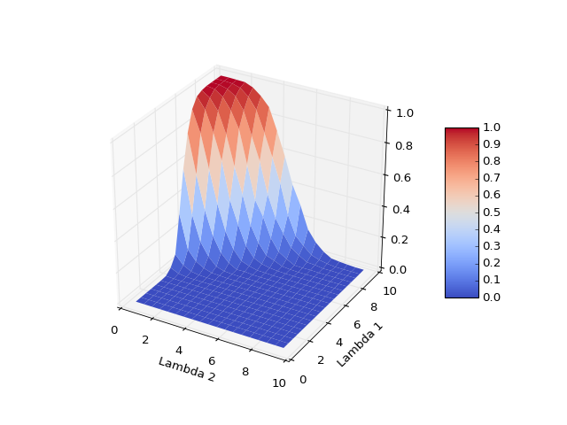

```
<function __main__.plotSurf>
```

```python
interact(plotSurf,
         n=(1, 100),
         t=(5, 100, 5),
         vartype=("est", "var", "err"))
```

#### Affichage des "contours"

```python
def plotContour(n, t, vartype="est"):
    limits = np.array([0, 0.01, 0.1, 0.25, 0.5, 0.75, 0.9, 0.99, 1])
    if vartype=="est":
        Z = extractZ(n, t, matrix_est)
    elif vartype=="var":
        Z = extractZ(n, t, matrix_var)
        limits = np.max(Z) * limits
    elif vartype=="err":
        Z = extractZ(n, t, matrix_err)
        limits = np.max(Z) * limits

    fig = plt.figure()

    contf = plt.contourf(X, Y, Z,
                         limits,
                         cmap=cm.coolwarm,
                         origin='lower'
                        )

    plt.xlabel("Lambda 2")
    plt.ylabel("Lambda 1")

    cbar = fig.colorbar(contf)
    plt.show()
```

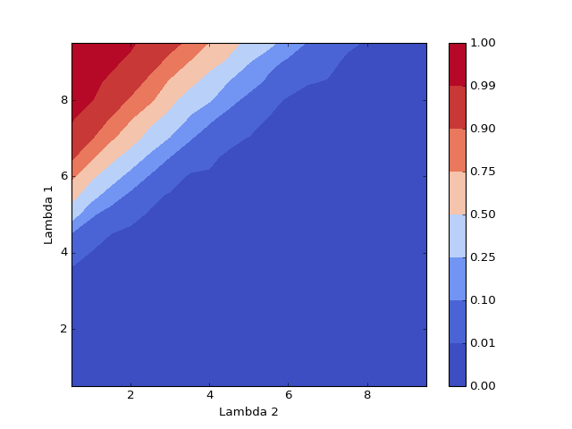

```
<function __main__.plotContour>
```

```python
interact(plotContour,
         n=(1, 100),
         t=(5, 100, 5),
         vartype=("est", "var", "err"))
```

```python
vals = np.arange(5,100,5)
print(len(vals))
```

```
19
```

```python
vals = np.arange(5,100,5)

X_, Y_ = np.meshgrid(vals, vals)

def extractZ_bis(l1,l2,matrix):
    l1_index = l1*2 - 1
    l2_index = l2*2 - 1
    Z = np.zeros((19,19), dtype=np.float32)
    for n in range(19):
        for t in range(19):
            Z[n,t] = matrix[n*5, t, l1_index, l2_index]
    return Z
```

```python
def plotContour_bis(l1, l2, vartype="est"):
    limits = np.array([0, 0.01, 0.1, 0.25, 0.5, 0.75, 0.9, 0.99, 1])
    if vartype=="est":
        Z = extractZ_bis(l1, l2, matrix_est)
    elif vartype=="var":
        Z = extractZ_bis(l1, l2, matrix_var)
        limits = np.max(Z) * limits
    elif vartype=="err":
        Z = extractZ_bis(l1, l2, matrix_err)
        limits = np.max(Z) * limits

    fig = plt.figure()

    contf = plt.contourf(X_, Y_, Z,
                         limits,
                         cmap=cm.coolwarm,
                         origin='lower'
                        )

    plt.xlabel("Temps t")
    plt.ylabel("Seuil n")

    cbar = fig.colorbar(contf)
    plt.show()
```

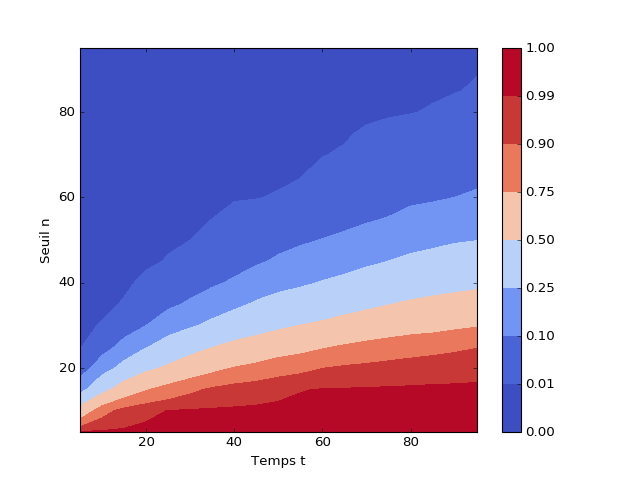

```
<function __main__.plotContour_bis>
```

```python
interact(plotContour_bis,
         l1=(0.5, 10, 0.5),
         l2=(0.5, 10, 0.5),
         vartype=("est", "var", "err"))
```

### Méthode de l'entropie croisée

Lorsque le seuil à dépasser `n` devient grand, la probabilité à estimer est très faible, l'évènement est très rare. Il s'agit alors d'utiliser la méthode CE pour estimer correctement cette probabilité.

Une approche mathématique du problème a été réalisée et est lisible [ici](http://naascraft.github.io/SMC/demo.pdf). On tentera pour une prochaine fois d'exploiter le module `sympy` qui permet l'affichage de LaTeX dans le notebook.

Pour mettre en place cette méthode d'estimation, il va nous falloir construire :

- La recherche de (`lambda_1, lambda_2`) optimaux pour minimiser l'entropie croisée :
  - Fonction de passage à itérer pour déterminer le couple suivant
  - Critère d'arrêt
- Le calcul de `p(n,t)` avec cette nouvelle distribution

```python
# params :
#   + W(x, l1, l2)
#   + X as list of (times1, times2, over)
#   + past and original lambda as (lambda_1, lambda_2)
def nextLambda(W, X, pastLambda, originLambda, gamma):
    length = len(X)
    num1 = np.zeros(length, dtype=np.float32)
    denum1 = np.zeros(length, dtype=np.float32)
    num2 = np.zeros(length, dtype=np.float32)
    denum2 = np.zeros(length, dtype=np.float32)
    k = 0

    for xi in X:
        times1, times2, max_l = xi
        over = max_l >= gamma
        ma, md = len(times1), len(times2)
        lkhratio = W(xi, originLambda, pastLambda)

        num1[k] = over * lkhratio * ma
        denum1[k] = over * lkhratio * sum(times1)
        num2[k] = over * lkhratio * md
        denum2[k] = over * lkhratio * sum(times2)

        k += 1

    newLambda = (np.sum(num1)/np.sum(denum1), np.sum(num2)/np.sum(denum2))
    return newLambda
```

La fonction que l'on vient de définir correspond à la relation de récurrence obtenue dans l'approche mathématique de la méthode de l'entropie croisée appliquée à notre problème. Plus précisément :

[figure not shown]

Avec les notations du [document mentionné](http://naascraft.github.io/SMC/demo.pdf).

```python
# params:
#   + x as (times1, times2, over)
#   + lambdas as (lambda1, lambda2)
def lkhRatio_exp(x, l1, l2):
    times1, times2, _ = x
    l1_1, l1_2 = l1
    l2_1, l2_2 = l2
    ma, md = len(times1), len(times2)
    sa, sd = sum(times1), sum(times2)

    const = (l1_1/l2_1)**ma * (l1_2/l2_2)**md
    toexp = (l2_1-l1_1)*sa + (l2_2 - l1_2)*sd

    return const*np.exp(toexp)
```

Cette fonction correspond au calcul du rapport de vraisemblance, pour les processus des temps d'inter-arrivées et de service. La forme simplifiée de ce calcul provient directement de la famille exponentielle des distributions.

```python
def genXasTimes(n, t, l1, l2, N, maxKeep):
    Xlist, temp = [], []

    for i in range(0,N):
        X = queue_exp(n, t, l1, l2, times=True)
        _1, _2, max_l = X
        Xlist += [X]

        # on stocke max_l dans temp
        temp += [max_l]

    # On trie temp en extrayant les indices
    indices = sorted(range(N), key=lambda k: temp[k])
    gamma = temp[indices[-maxKeep]]
    if gamma >= n: gamma = n

    Xlist = [Xlist[k] for k in indices]

    return Xlist, gamma
```

```python
# params:
#   + original lambdas as (lambda1, lambda2)
#   + n and t
#   + N (number of queues to sample at each step)
#   + threshold epsilon
#   + percentage of best queues to keep
def crossEntropyOptimal(originLambda, n, t, N, percentKeep):
    l1, l2 = originLambda
    maxKeep = int(math.ceil(N*percentKeep))
    pastLambda = originLambda
    step=0

    #first sample
    tim = time()
    Xlist, gamma = genXasTimes(n, t, l1, l2, N, maxKeep)

    if (gamma == n): newLambda=pastLambda

    while (gamma < n):
        step += 1
        begin_time = time()

        newLambda = nextLambda(lkhRatio_exp, Xlist, pastLambda, originLambda, gamma)

        #new sample
        l1, l2 = newLambda
        Xlist, gamma = genXasTimes(n, t, l1, l2, N, maxKeep)

        #error computation
        o_l1, o_l2 = pastLambda
        error = math.sqrt((l1-o_l1)**2 + (l2-o_l2)**2)

        #reset pastLambda
        pastLambda = newLambda

        #step info output
        print("Step {0} : current threshold = {1}, duration = {2}".format(
              step, gamma, time()-begin_time))

    return newLambda
```

La fonction ci-dessus permet d'obtenir le jeu (`lambda_1`, `lambda_2`) optimal au sens de l'entropie croisée. Elle itère la relation de récurrence (`nextLambda`) jusqu'à ce que le critère d'arrêt soit atteint.

Conformément à la proposition de N. Chopin dans son cours de Simulation et Monte Carlo, on gardera seulement un certain pourcentage (valeur proposée de 10%) des échantillons les meilleurs au sens de la fonction dont on cherche à estimer l'espérance (ici, l'indicatrice de dépassement), pour construire une suite de seuils `gamma` qui converge vers `n`.

On pourra alors échantillonner selon ce paramètre optimal, et normaliser par le rapport de vraisemblance associé dans la construction de notre estimateur CE (qui suit le même principe que l'estimateur CMC à cette normalisation près).

```python
def estCE(n, t, N, N1, lambdas, rho):
    # calcul du nouveau (l1,l2)
    print("Cross Entropy algorithm for optimal tilting parameter extraction\n")
    o_l1, o_l2 = lambdas
    print("Initial set : {0} , {1}".format(o_l1, o_l2))
    l1, l2 = crossEntropyOptimal(originLambda=lambdas,
                                 n=n, t=t, N=N,
                                 percentKeep=rho)
    print("Optimal set : {0} , {1}".format(l1, l2))

    # simulation de N1 files selon l1, l2
    Xlist = [queue_exp(n,t,l1,l2,times=True) for i in range(N1)]

    # calcul de l'estimateur
    toSum = np.zeros(N1, dtype=np.float32)
    for i in range(N1):
        X = Xlist[i]
        _1, _2, ml = X
        over = ml >= n

        toSum[i] = over * lkhRatio_exp(X, lambdas, (l1,l2))

    return (np.sum(toSum) / N1 , Xlist)
```

```python
def varCE(n, Xlist, est):
    var_sum = 0.
    for X in Xlist:
        _1, _2, ml = X
        if ml >= n:
            var_sum += (1-est)**2
        else:
            var_sum += est**2
    return var_sum/len(Xlist)
```

### Comparaison des estimateurs CE et CMC

```python
def relativeErrorCE(n, t, N, N1, lambdas, rho):
    estimator, Xlist = estCE(n, t, N, N1, lambdas, rho)
    sigma = math.sqrt(varCE(n, Xlist, estimator))

    if estimator == 0: return "infinity"
    else: return sigma/estimator
```

```python
def relativeErrorCMC(n, t, lambda_1, lambda_2, N1):
    Xlist = generateX(t, lambda_1, lambda_2, N1)
    estimator = estCMC(Xlist, n)
    sigma = math.sqrt(varCMC(Xlist, estimator, n))

    if estimator == 0: return "infinity"
    else: return sigma/estimator
```

**Cas 1** : On se place dans un cas où la probabilité à estimer n'est pas faible (de l'ordre de 0.5). On choisit donc (lambda_1 = 5, lambda_2 = 5) et on cherche à estimer la probabilité de dépasser le seuil n=20 avant la date t=40.

```python
reCE = relativeErrorCE(n=20, t=40, N=100, N1=1000,
                      lambdas=(5.,5.), rho=0.1)
print(reCE)
```

```
Cross Entropy algorithm for optimal tilting parameter extraction

Initial set : 5.0 , 5.0
Optimal set : 5.0 , 5.0
0.877446012256
```

```python
reCMC = relativeErrorCMC(n=20, t=40,
                        lambda_1=5., lambda_2=5.,
                        N1=1000)
print(reCMC)
```

```
0.900885232923
```

**Cas 2** : Cette fois, on se place dans un cadre où la probabilité de dépassement est très faible. On choisit donc (lambda_1 = 0.3, lambda_2 = 0.7), et on cherche à estimer la probabilité de dépasser le seuil n=20 avant la date t=40.

```python
reCE = relativeErrorCE(n=20, t=40, N=100, N1=1000,
                      lambdas=(0.3,0.7), rho=0.1)
print(reCE)
```

```
Cross Entropy algorithm for optimal tilting parameter extraction

Initial set : 0.3 , 0.7
Step 1 : current threshold = 7, duration = 0.00699996948242
Step 2 : current threshold = 12, duration = 0.0090000629425
Step 3 : current threshold = 20, duration = 0.00799989700317
Optimal set : 0.596396148205 , 0.344798505306
11392234.7406
```

```python
reCMC = relativeErrorCMC(n=20, t=40,
                        lambda_1=0.3, lambda_2=0.7,
                        N1=1000)
print(reCMC)
```

```
infinity
```